# Assignment

# Q1

## Part 1

The data set may be explored by using the following commands:

```r
CPU <- read.csv("CPU_Performance.csv")
head(CPU)
```

```
##   CycleTime MinimumMainMemory MaximumMainMemory CacheSize
## 1       125               256              6000       256
## 2        29              8000             32000        32
## 3        29              8000             32000        32
## 4        29              8000             32000        32
## 5        29              8000             16000        32
## 6        26              8000             32000        64
##   MinimumNumberOfChannels MaximumNumberOfChannels Performance
## 1                      16                     128         198
## 2                       8                      32         269
## 3                       8                      32         220
## 4                       8                      32         172
## 5                       8                      16         132
## 6                       8                      32         318
```

```r
names(CPU)
```

```
## [1] "CycleTime"               "MinimumMainMemory"
## [3] "MaximumMainMemory"       "CacheSize"
## [5] "MinimumNumberOfChannels" "MaximumNumberOfChannels"
## [7] "Performance"
```

```r
dim(CPU)
```

```
## [1] 209   7
```

```r
summary(CPU)
```

```
##    CycleTime      MinimumMainMemory MaximumMainMemory   CacheSize
##  Min.   :  17.0   Min.   :   64     Min.   :   64     Min.   :  0.00
##  1st Qu.:  50.0   1st Qu.:  768     1st Qu.: 4000     1st Qu.:  0.00
##  Median : 110.0   Median : 2000     Median : 8000     Median :  8.00
##  Mean   : 203.8   Mean   : 2868     Mean   :11796     Mean   : 25.21
##  3rd Qu.: 225.0   3rd Qu.: 4000     3rd Qu.:16000     3rd Qu.: 32.00
##  Max.   :1500.0   Max.   :32000     Max.   :64000     Max.   :256.00
##  MinimumNumberOfChannels MaximumNumberOfChannels  Performance
##  Min.   : 0.000          Min.   :  0.00          Min.   :   6.0
##  1st Qu.: 1.000          1st Qu.:  5.00          1st Qu.:  27.0
##  Median : 2.000          Median :  8.00          Median :  50.0
##  Mean   : 4.699          Mean   : 18.27          Mean   : 105.6
##  3rd Qu.: 6.000          3rd Qu.: 24.00          3rd Qu.: 113.0
##  Max.   :52.000          Max.   :176.00          Max.   :1150.0
```

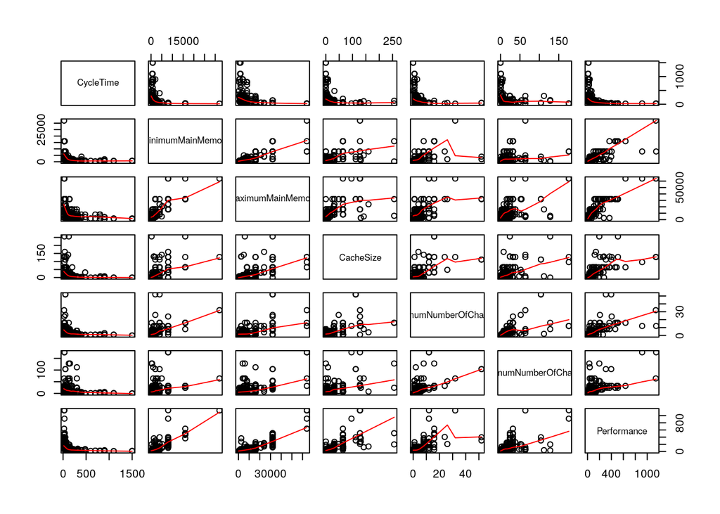

```r
pairs(CPU,panel = panel.smooth)
```

```r
cor(CPU, method = "pearson")
```

```
##                          CycleTime MinimumMainMemory MaximumMainMemory
## CycleTime                1.0000000        -0.3356422        -0.3785606
## MinimumMainMemory       -0.3356422         1.0000000         0.7581573
## MaximumMainMemory       -0.3785606         0.7581573         1.0000000
## CacheSize               -0.3209998         0.5347291         0.5379898
## MinimumNumberOfChannels -0.3010897         0.5171892         0.5605134
## MaximumNumberOfChannels -0.2505023         0.2669074         0.5272462
## Performance             -0.3070821         0.7949233         0.8629942
##                          CacheSize MinimumNumberOfChannels
## CycleTime               -0.3209998              -0.3010897
## MinimumMainMemory        0.5347291               0.5171892
## MaximumMainMemory        0.5379898               0.5605134
## CacheSize                1.0000000               0.5822455
## MinimumNumberOfChannels  0.5822455               1.0000000
## MaximumNumberOfChannels  0.4878458               0.5482812
## Performance              0.6626135               0.6089025
##                         MaximumNumberOfChannels Performance
## CycleTime                            -0.2505023  -0.3070821
## MinimumMainMemory                     0.2669074   0.7949233
## MaximumMainMemory                     0.5272462   0.8629942
## CacheSize                             0.4878458   0.6626135
## MinimumNumberOfChannels               0.5482812   0.6089025
## MaximumNumberOfChannels               1.0000000   0.6052193
## Performance                           0.6052193   1.0000000
```

It can be seen that the data set has 6 predictive features and one response variable, Performance.

## Part 2

Select Max Main Memory bacause it has the highest correlation coefficient and the most constant variance compared to the other predictors. Cycle time is expluded because of the non-linear relationship.

```r
library(tidyverse)
lm(Performance ~ MaximumMainMemory, data = CPU) %>% summary()
```

```
##
## Call:
## lm(formula = Performance ~ MaximumMainMemory, data = CPU)
##
## Residuals:
##     Min      1Q  Median      3Q     Max
## -230.75  -36.06    3.31   29.33  426.50
##
## Coefficients:
##                     Estimate Std. Error t value Pr(>|t|)
## (Intercept)       -3.400e+01  8.001e+00   -4.25 3.24e-05 ***
## MaximumMainMemory  1.184e-02  4.816e-04   24.58  < 2e-16 ***
## ---
## Signif. codes:  0 '***' 0.001 '**' 0.01 '*' 0.05 '.' 0.1 ' ' 1
##
## Residual standard error: 81.45 on 207 degrees of freedom
## Multiple R-squared:  0.7448, Adjusted R-squared:  0.7435
## F-statistic:   604 on 1 and 207 DF,  p-value: < 2.2e-16
```

The accepted model is :

$$Y_{Perf} = - 34 + 0.0118 \times \text{MaxMem}$$

## Part 3

Produce a multiple linear regression with all the attributes:

```r
lm.Perf_fit <- lm(Performance~., data = CPU)
summary(lm.Perf_fit)
```

```
##
## Call:
## lm(formula = Performance ~ ., data = CPU)
##
## Residuals:
##     Min      1Q  Median      3Q     Max
## -195.84  -25.17    5.41   26.53  385.75
##
## Coefficients:
##                           Estimate Std. Error t value Pr(>|t|)
## (Intercept)             -5.590e+01  8.045e+00  -6.948 4.99e-11 ***
## CycleTime                4.886e-02  1.752e-02   2.789  0.00579 **
## MinimumMainMemory        1.529e-02  1.827e-03   8.371 9.42e-15 ***
## MaximumMainMemory        5.571e-03  6.418e-04   8.680 1.33e-15 ***
## CacheSize                6.412e-01  1.396e-01   4.594 7.64e-06 ***
## MinimumNumberOfChannels -2.701e-01  8.557e-01  -0.316  0.75263
## MaximumNumberOfChannels  1.483e+00  2.201e-01   6.738 1.64e-10 ***
## ---
## Signif. codes:  0 '***' 0.001 '**' 0.01 '*' 0.05 '.' 0.1 ' ' 1
##
## Residual standard error: 59.99 on 202 degrees of freedom
## Multiple R-squared:  0.8649, Adjusted R-squared:  0.8609
## F-statistic: 215.5 on 6 and 202 DF,  p-value: < 2.2e-16
```

Minimum Number of Channels is an non-significant parameter so it is removed,

```r
lm.Perf_fit <- lm(Performance~.-MinimumNumberOfChannels, data = CPU)
summary(lm.Perf_fit)
```

```
##
## Call:
## lm(formula = Performance ~ . - MinimumNumberOfChannels, data = CPU)
##
## Residuals:
##     Min      1Q  Median      3Q     Max
## -193.39  -24.94    5.77   26.65  389.66
##
## Coefficients:
##                           Estimate Std. Error t value Pr(>|t|)
## (Intercept)             -5.608e+01  8.007e+00  -7.004 3.58e-11 ***
## CycleTime                4.912e-02  1.746e-02   2.813  0.00539 **
## MinimumMainMemory        1.518e-02  1.788e-03   8.490 4.34e-15 ***
## MaximumMainMemory        5.561e-03  6.397e-04   8.694 1.18e-15 ***
## CacheSize                6.296e-01  1.344e-01   4.686 5.11e-06 ***
## MaximumNumberOfChannels  1.460e+00  2.076e-01   7.032 3.05e-11 ***
## ---
## Signif. codes:  0 '***' 0.001 '**' 0.01 '*' 0.05 '.' 0.1 ' ' 1
##
## Residual standard error: 59.86 on 203 degrees of freedom
## Multiple R-squared:  0.8648, Adjusted R-squared:  0.8615
## F-statistic: 259.7 on 5 and 203 DF,  p-value: < 2.2e-16
```

All parameters are significant, therefore the model is accepted as optimal by the method of backward elimination

## Part 4

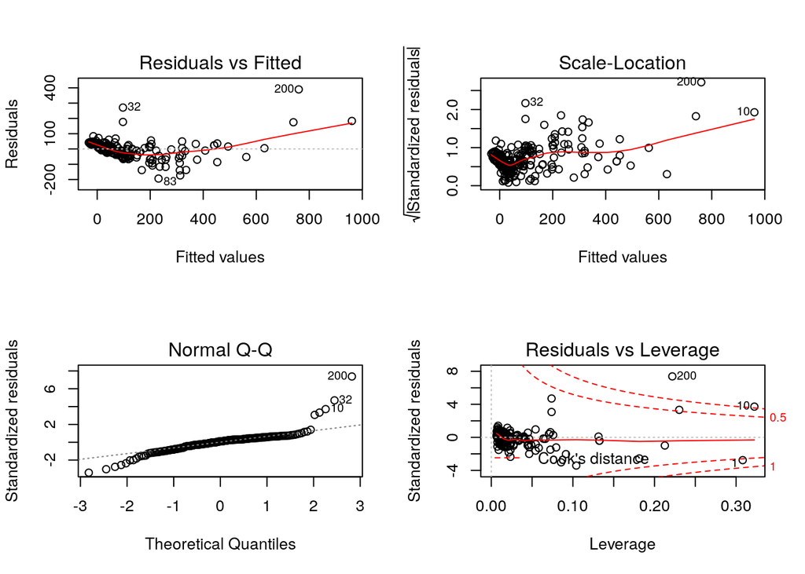

```r
layout(matrix(1:4, nrow = 2))
plot(lm.Perf_fit)
```

## Part 5

The residuals have a heteroskedastic tendancy and hence an appropriate transform would be a concave transform such as $\sqrt$:

```r
lm.trans <- lm(sqrt(Performance) ~ . - MinimumNumberOfChannels,data = CPU)
summary(lm.trans)
```

```
##
## Call:
## lm(formula = sqrt(Performance) ~ . - MinimumNumberOfChannels,
##     data = CPU)
##
## Residuals:
##     Min      1Q  Median      3Q     Max
## -6.1899 -0.8823 -0.1141  0.7133  8.8331
##
## Coefficients:
##                           Estimate Std. Error t value Pr(>|t|)
## (Intercept)              3.987e+00  2.284e-01  17.458  < 2e-16 ***
## CycleTime               -9.638e-04  4.980e-04  -1.935   0.0544 .
## MinimumMainMemory        3.573e-04  5.100e-05   7.007 3.52e-11 ***
## MaximumMainMemory        2.165e-04  1.824e-05  11.864  < 2e-16 ***
## CacheSize                3.640e-02  3.832e-03   9.497  < 2e-16 ***
## MaximumNumberOfChannels  2.435e-02  5.922e-03   4.111 5.72e-05 ***
## ---
## Signif. codes:  0 '***' 0.001 '**' 0.01 '*' 0.05 '.' 0.1 ' ' 1
##
## Residual standard error: 1.707 on 203 degrees of freedom
## Multiple R-squared:  0.9037, Adjusted R-squared:  0.9013
## F-statistic: 380.9 on 5 and 203 DF,  p-value: < 2.2e-16
```

Following the transform the `CycleTime` parameter is non-significant and so it will be removed:

```r
lm.trans <- lm(sqrt(Performance) ~ . -MinimumNumberOfChannels- CycleTime,
               data = CPU)
summary(lm.trans)
```

```
##
## Call:
## lm(formula = sqrt(Performance) ~ . - MinimumNumberOfChannels -
##     CycleTime, data = CPU)
##
## Residuals:
##     Min      1Q  Median      3Q     Max
## -6.2229 -0.9605 -0.0698  0.7882  8.9651
##
## Coefficients:
##                          Estimate Std. Error t value Pr(>|t|)
## (Intercept)             3.691e+00  1.706e-01  21.632  < 2e-16 ***
## MinimumMainMemory       3.631e-04  5.125e-05   7.085 2.22e-11 ***
## MaximumMainMemory       2.210e-04  1.821e-05  12.134  < 2e-16 ***
## CacheSize               3.723e-02  3.834e-03   9.712  < 2e-16 ***
## MaximumNumberOfChannels 2.481e-02  5.957e-03   4.166 4.58e-05 ***
## ---
## Signif. codes:  0 '***' 0.001 '**' 0.01 '*' 0.05 '.' 0.1 ' ' 1
##
## Residual standard error: 1.719 on 204 degrees of freedom
## Multiple R-squared:  0.9019, Adjusted R-squared:    0.9
## F-statistic: 468.9 on 4 and 204 DF,  p-value: < 2.2e-16
```

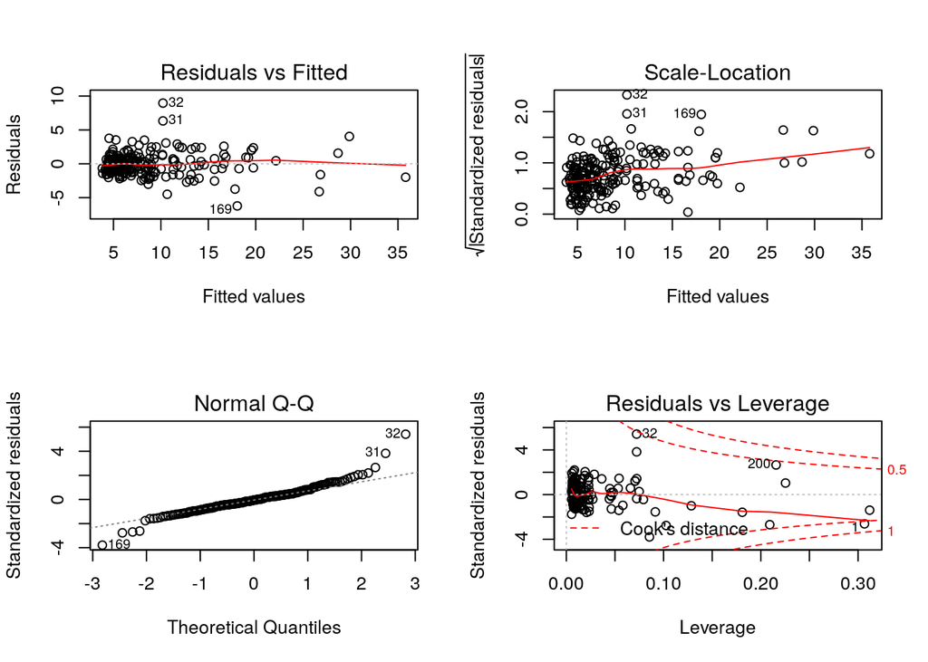

```r
layout(matrix(1:4, nrow = 2))
plot(lm.trans)
```

All parameters are significant and the residuals appear Gaussian and hence the model will be accepted as optimal by the process of backward elimination.